# Lab3

YenTing Shen

1/29/2019

# R4L Lab 3

### Over All Question

The question that we will try to answer as a team is if smoking lowers a person’s overall health. This question is important because a lot of people worldwide smoke cigarettes, and it is very useful to know if they have a detrimental effect on one’s health and well-being.

### Team Plot

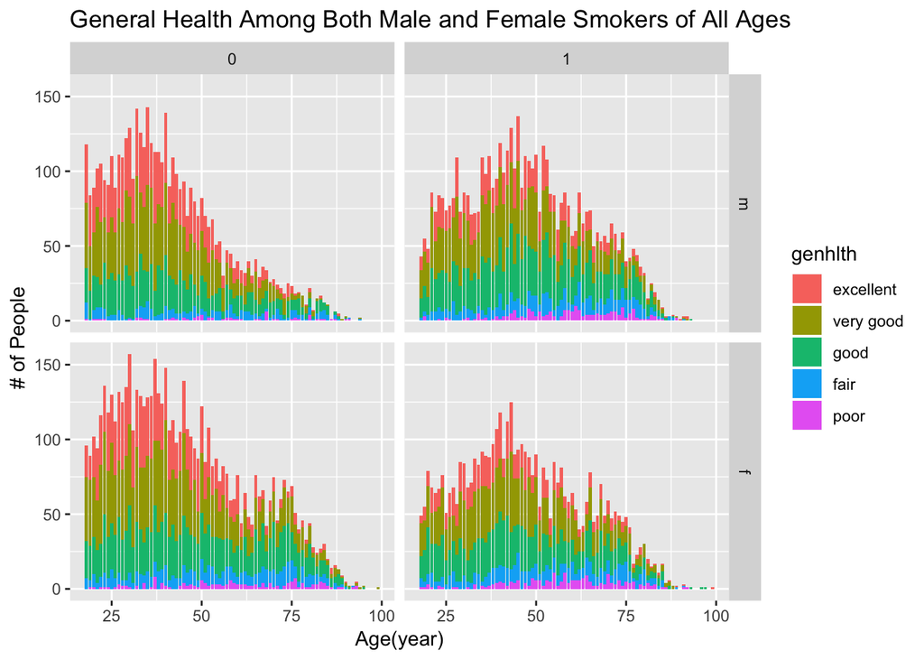

```r
ggplot(data = cdc) +
  geom_bar(mapping = aes(x = age,fill=genhlth)) +
  facet_grid(gender ~ smoke100)+
    xlab('Age(year)')+
    ylab('# of People')+
    ggtitle('General Health Among Both Male and Female Smokers of All Ages')
```

### Conclusion

This graph shown above is a histogram of age, separated into four groups: male smokers, male non-smokers, female smokers, and female non-smokers. Additionally, each bar is color-coded to reflect the measure of general health: excellent, very good, good, fair, and poor. One thing that is noticeable from this graph is the number of people with the fair and poor health indicator is much higher for smokers than it is for non-smokers. Additionally, the number of people with very good and excellent health is higher for non-smokers as opposed to smokers. This evidence leads us to conclude that individuals who have smoked more than 100 cigarettes in their lifetime have overall lower general health than individuals who are not smokers.

### Team’s Recommendation

From the plots we’ve made, smoking indicates a very strong negative health effects on both male and females of all ages. Our recommendation is for everyone to quit smoking and have better life that it better to you and for the people around you.

# Individual Plots

### Jason Giblin

The following is a graph of height versus weight, with different colors differentiating between smokers and non smokers. I, Jason Giblin, created this plot. In this data set, height is measured in inches, and weight is measured in pounds. Non-smoker is defined as a person who has smoked less than 100 cigarettes in their life, and smoker is defined as someone who has smoked at least 100 cigarettes in their life. This plot shows that in general, as height increases, weight also increases, as expected. Another interesting bit about this graph is that it appears smokers and non-smokers don’t differ by too much in height and weight. With the exception of the two tails of the graph, the best fit lines for smokers and non-smokers are nearly identical. Some adjustments I made to the basic plot was first of all, adding the smooth best fit curve. Additionally, I used colors to differentiate between 2 groups: smokers and non-smokers. I used this color pattern for both the scatter plot and smooth curve. I changed the key to the right of the graph to say “non-smoker” and “smoker.” Lastly, I added labels for the title of the graph, and intuitive labels for each of the axes.

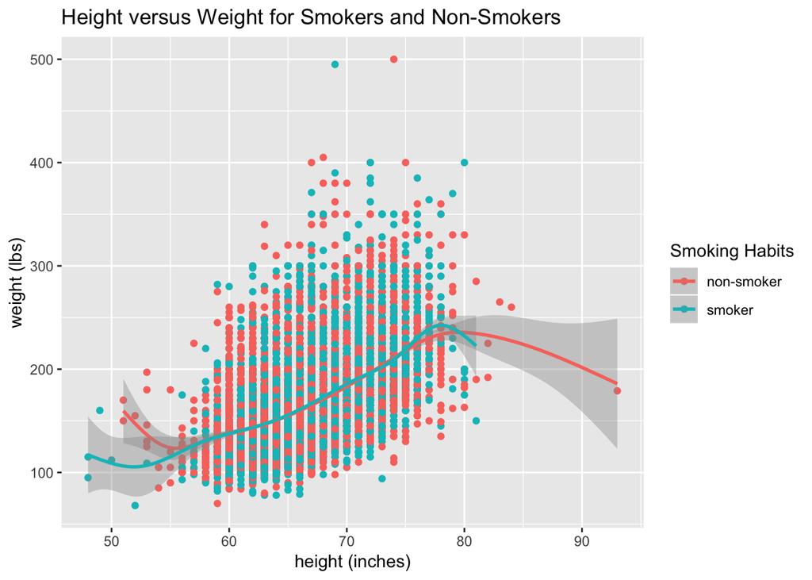

```r
ggplot(data=cdc, aes(x = height, y = weight, color=as.factor(smoke100)))+
  geom_point()+
  geom_smooth()+
  xlab('height (inches)')+
  ylab('weight (lbs)')+
  ggtitle('Height versus Weight for Smokers and Non-Smokers')+
  scale_color_discrete(name = 'Smoking Habits',
                       labels = c('non-smoker', 'smoker'))
```

### Tiger Su

The following code expresses how general health distributes in different ages of people. From the CDC data, we have five different conditions of health“excellent, very good, good, fair, and poor”. From the plot I created blew, it is very clear that the health condition of “good, very good, excellent” is the majority of the server population. There is an interesting fact that even at of 18, there are still a decent amount of people under “fair” and “poor” health condition. At the age around 30, the percentage of “poor” has a significant increase to a somewhat stable percentage. In the meantime, the percentage of “excellent, very good, good, fair, and poor” start decreasing after age around 55. In conclusion, it is very obvious that general health is distributed differently in different age group. In general, the older you get, the poorer health you get, but it decreases in a smaller amount, which means most people are still living over “good” health condition.

In the “ggplot i created, I used CDC as my data, and use”geom_bar" function to create a bar graph. Setting the x-axes at age and general health as my bars, which are filled with different colors. In order to make the plot looks more clear, I used “coord_flip()” function to flip the graph, “ggtitle()” function to make a new title, “xlab()” and “ylab()” to title both x-axes and y-axes. For aesthetic purposes, I changed the format of a different condition of general health by using “theme()” function. Legend. position = “top” command let me move it to the top of the graph.

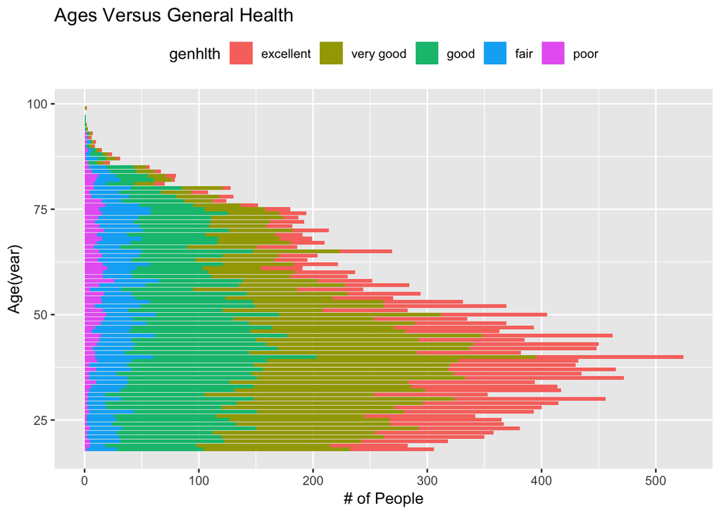

```r
#Tiger Su
ggplot(data = cdc) +
  geom_bar(mapping = aes(x =age , fill=genhlth ))+
  coord_flip() +
  theme(legend.position = "top")+
  ggtitle('Ages Versus General Health')+
  xlab('Age(year)')+
  ylab('# of People')
```

### Yen-Ting Shen

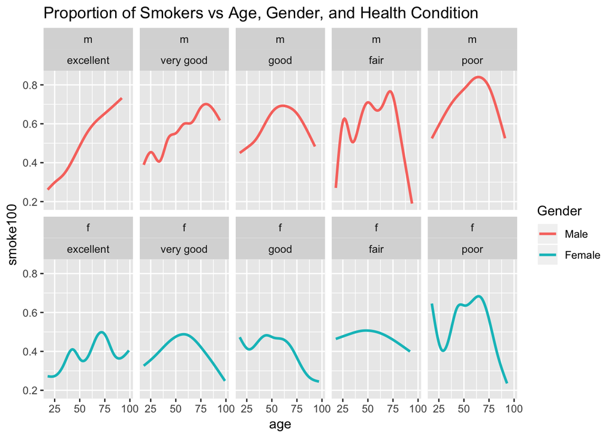

```r
ggplot(data = cdc)+
  geom_smooth(mapping = aes(x=age, y=smoke100, color=gender), se=FALSE)+
  facet_wrap(gender~genhlth, nrow = 2)+
  ggtitle('Proportion of Smokers vs Age, Gender, and Health Condition')+
  scale_color_discrete(name = 'Gender',
                       labels = c('Male', 'Female'))
```

### Emery Schattinger

The graph below was make by Emery Schattinger, it shows how smoking can cause your health to have problems by having a graph that compared the health of non smokers and the health of smokers. With the graph you can see that with the group of people who smoke, they tend to have more people with lower health quality and fewer people with better health. When I was going about making the graph, I first picked which variaables I wanted to use, then I desided to split the data up into smokers vs non smokers so it wouldn’t be hard to compare the two. Then I thought it would be a good idea to change the colors for the different Health Qualities so you know exactly which two section to compare to. I like thiis graph because it was simple and strait to the point.

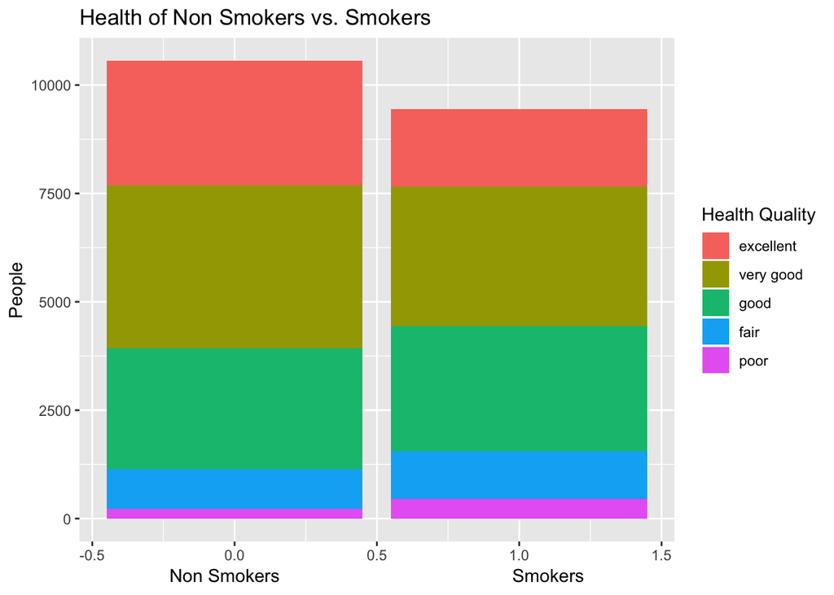

```r
ggplot(data = cdc) +
  geom_bar(mapping = aes(x = smoke100, fill = genhlth)) +
  ggtitle("Health of Non Smokers vs. Smokers") +
  labs(y= "People", x = "Non Smokers                                              Smokers")+
  labs(fill ="Health Quality")
```